# 03-Tarea

Teresa Ortiz

### Problema 1. Factorización

Realiza el ejercicio de clase.

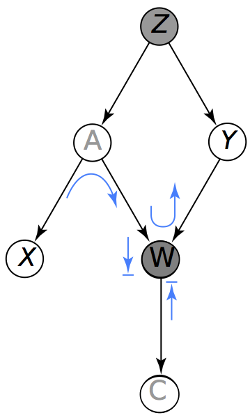

Con base en la gráfica de arriba demuestra algebráicamente que dados $(Z,W)$, tenemos que $X$ no es necesariamente independiente de $Y$.

### Problema 2. D-separación

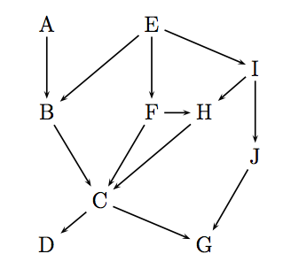

Cuáles de los siguientes enunciados son ciertos, para cada falso escribe un camino activo.

- $B \perp H | E$
- $B \perp I | A,D,E$
- $A \perp E | G$
- $C \perp J$
- $A \perp I$
- $E \perp G | C$

### Problema 3. Modelos locales

En estos ejemplos construiremos modelos locales usando tablas de frecuencias. Utiliza los datos en el archivo admisiones.csv, en donde cada renglón representa a un alumno que solicitó entrar a una universidad, las variables son el departamento al que aplicó, el género del aplicante y su resultado (aceptación o rechazo).

- Considera la relación Genero -> Admisión (solo dos variables). Construye un modelo local con la tabla de frecuencias y explica qué relación observas entre estas dos variables.
- Considera ahora el modelo Género -> Departamento -> Admisión. Construye los dos modelos locales con las tablas de frecuencias correspondientes. Bajo este modelo, ¿cómo se explica la relación de Género con Admisión que observaste en el ejemplo anterior?
- Explica qué significa que no haya una flecha directa de Género a Admisión. Verifica tu respuesta calculando el porcentaje de admitidos para cada sexo dentro de cada departamento, y explica qué tienen qué ver estas tablas con la ausencia de una flecha directa de Género a Admisión.